# Design Declaration

## Required Effect Size by Sample Size

The diagnosis table shows that stage 1 (justice and threat frames) is well-powered at N = 2,000, while stage 2 (performance vignette) is severely underpowered under conservative effect size assumptions. This motivates the question: for a given sample size, how large does the true performance effect need to be to reach 80% power? Because each stage 1 cell receives N/4 respondents and the performance treatment splits those 50/50, the effective per-arm N for each conditional performance estimate is only N/8. Figure 2 traces how power varies jointly across effect sizes and total sample sizes.

```r
# helper function: a stripped-down single-cell design for the performance treatment
declare_cell_design <- function(N_cell, mu = 4, sigma = 2, tau_performance = 0.3) {

  # same logic as in the main design: baseline + performance shift + individual noise
  # but now we only have one binary treatment (performance yes/no)
  model <- declare_model(
    N = N_cell,
    U = rnorm(N_cell, 0, sigma),
    potential_outcomes(
      Y ~ mu + tau_performance * Z_performance + U,
      conditions = list(Z_performance = c(0, 1))
    )
  )

  # the quantity we want: average difference in support between performance and no-performance
  inquiry    <- declare_inquiry(ATE_Performance = mean(Y_Z_performance_1 - Y_Z_performance_0))
  # randomly assign half the cell to see the performance vignette
  assignment <- declare_assignment(Z_performance = complete_ra(N_cell, prob = 0.5))
  # observe the outcome for the assigned condition
  measurement <- declare_measurement(Y = reveal_outcomes(Y ~ Z_performance))
  # estimate the effect with robust ols
  estimator  <- declare_estimator(
    Y ~ Z_performance,
    .method = lm_robust, term = "Z_performance",
    inquiry = "ATE_Performance", label = "Performance"
  )

  model + inquiry + assignment + measurement + estimator
}

# define the range of effect sizes (tau) and total sample sizes to explore
# tau runs from 0.1 (tiny, d = 0.05) to 2.0 (very large, d = 1.0) in steps of 0.1
# n_totals are the total study sizes; each stage 1 cell gets n_total / 4 respondents,
# and the performance treatment splits those further 50/50 → n_total / 8 per arm
tau_vals <- seq(0.1, 2.0, by = 0.1)
n_totals <- c(1000, 1500, 2000, 2500, 3000)

# create one row per tau × n combination — 20 taus × 5 sample sizes = 100 designs
tau_n_grid <- expand.grid(tau = tau_vals, N_total = n_totals)

# instantiate a separate cell design for each row in the grid
# each design uses n_total / 4 as the within-cell n (one stage 1 group)
# and the corresponding tau as the assumed performance effect
designs_tau_n <- setNames(
  Map(
    function(tau, N_total)
      declare_cell_design(N_cell = N_total / 4, tau_performance = tau),
    tau_n_grid$tau, tau_n_grid$N_total
  ),
  # give each design a unique name so we can match results back to the grid later
  paste0("tau=", tau_n_grid$tau, ";N=", tau_n_grid$N_total)
)

# run 500 simulated experiments per design and record statistical power
diagnoses_tau_n <- diagnose_design(designs_tau_n, sims = 500)
```

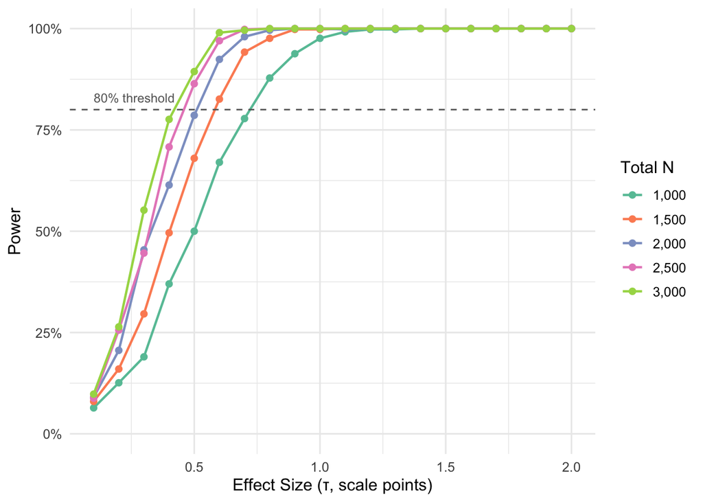

Figure 2: Statistical power for the performance treatment within a single Stage 1 cell as a function of effect size (τ) and total sample size. Per-arm N = N_total / 8. The dashed line marks the 80% power threshold; σ = 2; 500 simulations per design.

```r
# rebuild the lookup table with the same naming convention used for designs_tau_n
# so we can join simulation results back to their tau and n values for plotting
tau_n_lookup <- tau_n_grid |>
  mutate(design = paste0("tau=", tau, ";N=", N_total))

diagnoses_tau_n$diagnosands_df |>
  # attach tau and n_total columns to the simulation results
  left_join(tau_n_lookup, by = "design") |>
  # x-axis: effect size; y-axis: power; one coloured line per total sample size
  ggplot(aes(x = tau, y = power,
             color    = factor(N_total, labels = scales::comma(n_totals)),
             group    = factor(N_total))) +
  geom_line(linewidth = 0.8) +
  geom_point(size = 1.8) +
  # horizontal reference line at 80% — the conventional minimum acceptable power
  geom_hline(yintercept = 0.80, linetype = "dashed", color = "gray40", linewidth = 0.5) +
  annotate("text", x = 0.1, y = 0.83, label = "80% threshold",
           hjust = 0, size = 3.2, color = "gray40") +
  scale_color_brewer(palette = "Set2", name = "Total N") +
  # show power as a percentage and effect size in raw scale points
  scale_y_continuous(limits = c(0, 1), labels = percent_format(accuracy = 1)) +
  labs(x = "Effect Size (τ, scale points)", y = "Power") +
  theme_minimal(base_size = 12) +
  theme(legend.position = "right")
```

## References

Lachapelle, Jean. 2022. “Repression Reconsidered: Bystander Effects and Legitimation in Authoritarian Regimes.” *Comparative Politics* 54 (4): 695–716. https://doi.org/10.5129/001041522X16317396828722.

Przeworski, Adam. 2023. “Formal Models of Authoritarian Regimes: A Critique.” *Perspectives on Politics* 21 (3): 979–88. https://doi.org/10.1017/S1537592722002067.